# **Econometrics**

Autocorrelation: Quarter data car

Sujiao (Emma) ZHAO

2021/10/27 (updated: 2021-10-23)

First, we need to change to the folder where the dataset is located.

We need to read the auto_quarter_data dataset. $gas$ is the natural log of real per capita expenditure on gasoline. $price$ is the natural log of real price on gasoline. $income$ is the natural log of real per capita disposable personal income. $miles$ is the natural log of miles per gallon.

```r
library(haven) # import Stata data
auto <- read_dta("auto_quarter_data.dta")
```

We can do some descriptive statistics and show the first 10 observations:

```r
library(stargazer)
stargazer(as.data.frame(auto), type = "text")
```

```
##
## ========================================================================
## Statistic  N    Mean    St. Dev.    Min    Pctl(25)  Pctl(75)     Max
## ------------------------------------------------------------------------
## quarter   128 1,974.750  9.270   1,959.100 1,966.925 1,982.575 1,990.400
## gas       128  -7.763    0.120    -8.020    -7.836    -7.672    -7.606
## price     128   4.724    0.166     4.488     4.621     4.767     5.176
## income    128  -4.195    0.154    -4.505    -4.282    -4.106    -3.970
## miles     128   2.713    0.135     2.584     2.614     2.811     3.036
## ------------------------------------------------------------------------
```

```r
head(auto, 10)
```

```
## # A tibble: 10 x 5
##    quarter   gas price income miles
##      <dbl> <dbl> <dbl>  <dbl> <dbl>
##  1   1959. -8.02  4.68  -4.51  2.65
##  2   1959. -8.01  4.69  -4.49  2.65
##  3   1959. -8.02  4.69  -4.50  2.65
##  4   1959. -8.01  4.72  -4.49  2.65
##  5   1960. -8.02  4.71  -4.49  2.65
##  6   1960. -7.98  4.70  -4.49  2.65
##  7   1960. -8.00  4.72  -4.49  2.65
##  8   1960. -8.01  4.72  -4.50  2.65
##  9   1961. -8.01  4.71  -4.49  2.65
## 10   1961. -7.99  4.68  -4.48  2.65
```

We need to transform the data in “time series”:

```r
library(dplyr)
auto<-auto %>% mutate(t = dense_rank(quarter))
auto
```

```
## # A tibble: 128 x 6
##    quarter   gas price income miles     t
##      <dbl> <dbl> <dbl>  <dbl> <dbl> <int>
##  1   1959. -8.02  4.68  -4.51  2.65     1
##  2   1959. -8.01  4.69  -4.49  2.65     2
##  3   1959. -8.02  4.69  -4.50  2.65     3
##  4   1959. -8.01  4.72  -4.49  2.65     4
##  5   1960. -8.02  4.71  -4.49  2.65     5
##  6   1960. -7.98  4.70  -4.49  2.65     6
##  7   1960. -8.00  4.72  -4.49  2.65     7
##  8   1960. -8.01  4.72  -4.50  2.65     8
##  9   1961. -8.01  4.71  -4.49  2.65     9
## 10   1961. -7.99  4.68  -4.48  2.65    10
## # ... with 118 more rows
```

Suppose we want to estimate the following model

$$gas_t=β_0+β_1 income_t+β_2 price_t+u_t$$

and wish to test whether the disturbances are autocorrelated.

```r
library(stargazer)
reg1<-lm(gas~ income +price, data=auto)
stargazer(reg1, type="text", digits=8)
```

```
##
## =================================================
##                          Dependent variable:
##                     -----------------------------
##                                  gas
## -------------------------------------------------
## income                      0.70561340***
##                             (0.03373477)
##
## price                      -0.15028430***
##                             (0.03123107)
##
## Constant                   -4.09334200***
##                             (0.22475550)
##
## -------------------------------------------------
## Observations                     128
## R2                           0.77786280
## Adjusted R2                  0.77430860
## Residual Std. Error     0.05709702 (df = 125)
## F Statistic         218.85770000*** (df = 2; 125)
## =================================================
## Note:                 *p<0.1; **p<0.05; ***p<0.01
```

Keep residuals and constructs the lagged value of residuals.

```r
library(dplyr)
auto$res1<-reg1$residuals
auto<-auto %>% mutate(res1lag1 = lag(res1))
auto
```

```
## # A tibble: 128 x 8
##    quarter   gas price income miles     t     res1 res1lag1
##      <dbl> <dbl> <dbl>  <dbl> <dbl> <int>    <dbl>    <dbl>
##  1   1959. -8.02  4.68  -4.51  2.65     1 -0.0403  NA
##  2   1959. -8.01  4.69  -4.49  2.65     2 -0.0426  -0.0403
##  3   1959. -8.02  4.69  -4.50  2.65     3 -0.0474  -0.0426
##  4   1959. -8.01  4.72  -4.49  2.65     4 -0.0400  -0.0474
##  5   1960. -8.02  4.71  -4.49  2.65     5 -0.0477  -0.0400
##  6   1960. -7.98  4.70  -4.49  2.65     6 -0.00925 -0.0477
##  7   1960. -8.00  4.72  -4.49  2.65     7 -0.0244  -0.00925
##  8   1960. -8.01  4.72  -4.50  2.65     8 -0.0300  -0.0244
##  9   1961. -8.01  4.71  -4.49  2.65     9 -0.0412  -0.0300
## 10   1961. -7.99  4.68  -4.48  2.65    10 -0.0344  -0.0412
## # ... with 118 more rows
```

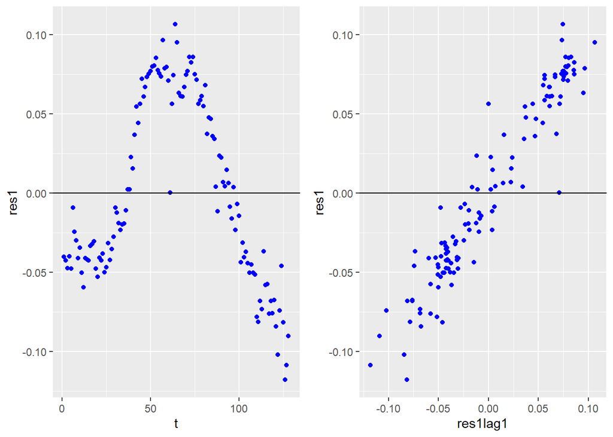

```r
library(ggplot2)
fig1<-ggplot(data = auto, aes(y = res1, x = t)) + geom_point(col = 'blue') + geom_abline(slope = 0)
fig2<-ggplot(data = auto, aes(y = res1, x = res1lag1)) + geom_point(col = 'blue') + geom_abline(slope = 0)
library(grid)
# Create a new page
grid.newpage()
# Next push the vissible area with a layout of 1 row and 2 columns using pushViewport()
pushViewport(viewport(layout = grid.layout(1,2)))

print(fig1, vp = viewport(layout.pos.row = 1, layout.pos.col = 1))
print(fig2, vp = viewport(layout.pos.row = 1, layout.pos.col = 2))
```

The `acf()` function in the R stats package computes and plots the autocorrelation functions of a time series.The broken horizontal lines on the plots correspond to approximate 95% confidence limits.

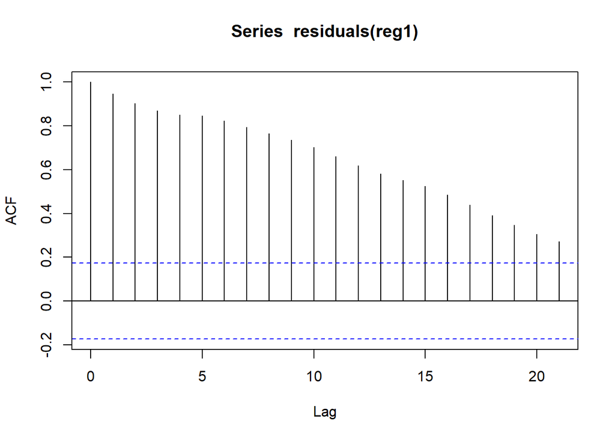

```r
library(stats)
acf(residuals(reg1))
```

The graphs indicate positive first order autocorrelation of residuals.

## Checking autocorrelation

Now let us look at a couple of commands that test for autocorrelation.

```r
library(lmtest)
dwtest(reg1)
```

```
##
##  Durbin-Watson test
##
## data:  reg1
## DW = 0.084511, p-value < 2.2e-16
## alternative hypothesis: true autocorrelation is greater than 0
```

```r
library(lmtest)
bgtest(reg1)
```

```
##
##  Breusch-Godfrey test for serial correlation of order up to 1
##
## data:  reg1
## LM test = 116.93, df = 1, p-value < 2.2e-16
```

So, in this case, there is evidence of autocorrelation.

## Dealing with autocorrelation

$\mbox{1. Estimate by OLS and use the Newey-West estimator}$

```r
library(sandwich)
# Normal SE
coeftest(reg1)
```

```
##
## t test of coefficients:
##
##              Estimate Std. Error t value  Pr(>|t|)
## (Intercept) -4.093342   0.224755 -18.212 < 2.2e-16 ***
## income       0.705613   0.033735  20.916 < 2.2e-16 ***
## price       -0.150284   0.031231  -4.812 4.225e-06 ***
## ---
## Signif. codes:  0 '***' 0.001 '**' 0.01 '*' 0.05 '.' 0.1 ' ' 1
```

```r
# Newey West SE
coeftest(reg1, vcov = NeweyWest)
```

```
##
## t test of coefficients:
##
##             Estimate Std. Error t value Pr(>|t|)
## (Intercept) -4.09334    1.54898 -2.6426 0.009279 **
## income       0.70561    0.23670  2.9811 0.003453 **
## price       -0.15028    0.13203 -1.1382 0.257202
## ---
## Signif. codes:  0 '***' 0.001 '**' 0.01 '*' 0.05 '.' 0.1 ' ' 1
```

$\mbox{2. Use Feasible Weighted Least Squares}$

```r
library(nlme)
mod.gls <- gls(gas~ income + price,
data=auto, correlation=corAR1(form = ~ t))
stargazer(mod.gls, type="text", digits=8)
```

```
##
## ===============================================
##                         Dependent variable:
##                     ---------------------------
##                                 gas
## -----------------------------------------------
## income                     0.33985260**
##                            (0.14043970)
##
## price                     -0.20910180***
##                            (0.03524613)
##
## Constant                  -5.42629500***
##                            (0.68875340)
##
## -----------------------------------------------
## Observations                    128
## Log Likelihood             341.77550000
## Akaike Inf. Crit.          -673.55100000
## Bayesian Inf. Crit.        -659.40940000
## ===============================================
## Note:               *p<0.1; **p<0.05; ***p<0.01
```